# Aaron's First Cleaning of the Data

This document describes and shows the first data cleaning done via R after the data file was uploaded to the R Server. We'll do most of the spatial display via ArcMap, but much of the data manipulation, analysis and non-spatial display via R.

```r
require(foreign)
getwd()
```

```
## [1] "/home/newmangr/OSI-Hedonic Project/OSI-Hedonic/writeup/02-AllData"
```

```r
HouseData = read.dbf("~/OSI-Hedonic Project/Data/GIS2R/allData.dbf")
```

```r
options(width = 160)
```

What's in this file? What is the underlying structure of the data? What are the variables? How many of them? What are their values?

```r
str(HouseData)
```

```
## 'data.frame':    51394 obs. of  67 variables:
##  $ COUNTY_ID : Factor w/ 5 levels "003","037","123",..: 2 2 2 2 2 2 2 2 2 2 ...
##  $ PIN       : Factor w/ 51367 levels "003-013024110022",..: 14879 14882 10056 17023 17024 12061 12063 12067 12068 12071 ...
##  $ CITY      : Factor w/ 74 levels "ANDOVER","ANOKA",..: 40 40 3 48 48 6 6 6 6 7 ...
##  $ LOT       : Factor w/ 809 levels "001","002","003",..: NA NA NA NA NA NA NA NA NA NA ...
##  $ ACRES_POLY: num  0.3 0.28 0.37 0.84 0.61 0.92 0.53 0.54 0.33 1.25 ...
##  $ ACRES_DEED: num  0 0 0 0 0 0 0 0 0 0 ...
##  $ USE1_DESC : Factor w/ 7 levels "100 Res 1 unit",..: 4 4 4 4 4 4 4 4 4 4 ...
##  $ HOMESTEAD : Factor w/ 3 levels "N","P","Y": 3 3 3 3 3 3 3 3 3 3 ...
##  $ EMV_LAND  : int  50600 53000 64200 118700 149400 84700 116400 101600 59300 40500 ...
##  $ EMV_BLDG  : int  135700 213100 121700 284900 599400 216600 441800 318700 178300 183300 ...
##  $ EMV_TOTAL : int  186300 266100 185900 403600 748800 301300 558200 420300 237600 223800 ...
##  $ TAX_CAPAC : int  1906 2713 1915 4277 8614 3075 5853 4283 2423 2367 ...
##  $ TOTAL_TAX : int  2088 3130 2300 4124 8211 3872 7381 5436 2921 2528 ...
##  $ XUSE1_DESC: Factor w/ 7 levels "BENEVOLENT INST. (CHEM. DEPT TRTMNT CTR)",..: NA NA NA NA NA NA NA NA NA NA ...
```

[output cut: 54 more lines]

```r
summary(HouseData)
```

```
##  COUNTY_ID              PIN                           CITY            LOT          ACRES_POLY      ACRES_DEED
##  003: 9479   139-254160010:    8   SAINT PAUL           : 8083   1      : 2249   Min.   : 0.00   Min.   : 0.00
##  037: 9677   139-254160030:    8   CITY OF WOODBURY     : 4938   2      : 2151   1st Qu.: 0.14   1st Qu.: 0.00
##  123:14057   139-250950090:    2   CITY OF SHAKOPEE     : 3113   3      : 2126   Median : 0.25   Median : 0.00
##  139: 6919   139-252310040:    2   BLAINE               : 2416   4      : 1959   Mean   : 0.37   Mean   : 0.11
##  163:11262   139-252310100:    2   CITY OF COTTAGE GROVE: 2121   5      : 1757   3rd Qu.: 0.34   3rd Qu.: 0.11
##              139-254160170:    2   CITY OF SAVAGE       : 1895   (Other):25624   Max.   :39.98   Max.   :40.00
##              (Other)      :51370   (Other)              :28828   NA's   :15528
##                                                  USE1_DESC     HOMESTEAD    EMV_LAND          EMV_BLDG         EMV_TOTAL         TAX_CAPAC       TOTAL_TAX
##  100 Res 1 unit                                       :18181   N: 7748   Min.   :   1800   Min.   :      0   Min.   :      0   Min.   :    0   Min.   :    0
##  COMMERCIAL-PREFFERED                                 :    3   P:  120   1st Qu.:  42200   1st Qu.: 104600   1st Qu.: 154000   1st Qu.:    0   1st Qu.:    0
##  EXEMPT                                               :    2   Y:43526   Median :  61700   Median : 131300   Median : 195200   Median :    0   Median : 1969
##  RESIDENTIAL                                          : 9672             Mean   :  68962   Mean   : 156701   Mean   : 225662   Mean   :  816   Mean   : 1866
##  RESIDENTIAL SINGLE FAMILY                            : 9478             3rd Qu.:  81000   3rd Qu.: 184700   3rd Qu.: 263200   3rd Qu.: 1684   3rd Qu.: 2762
##  RESIDENTIAL SINGLE FAMILY, RESIDENTIAL SINGLE FAMILY,:    1             Max.   :1955300   Max.   :1994500   Max.   :3437200   Max.   :25949   Max.   :49323
##  Single Family Dwelling, Platted Lot                  :14057
##                                     XUSE1_DESC                             DWELL_TYPE            HOME_STYLE      FIN_SQ_FT      GARAGE         GARAGESQFT
##  Muni Srvc Other                         :    4   SINGLE FAMILY DWELLING        :14057   One Story    : 7412   Min.   :  300   N   :  960   440     : 3251
##  RESIDENTIAL SINGLE FAMILY               :    2   S.FAM.RES                     : 9677   Two Story    : 4850   1st Qu.: 1092   Y   :33838   484     : 1835
##  BENEVOLENT INST. (CHEM. DEPT TRTMNT CTR):    1   RESIDENTIAL SINGLE FAMILY     : 9478   SPLIT LEVL   : 4140   Median : 1454   NA's:16596   528     : 1793
##  CDA,ECON DEV/HABITAT FOR HUMANITY/MHFA  :    1   Single-Family / Owner Occupied: 7699   TWO STORY    : 3834   Mean   : 1648                440.0000: 1352
##  Church-Other Res                        :    1   Townhouse                     : 2994   Bungalow     : 3610   3rd Qu.: 1978                576     : 1231
##  (Other)                                 :    2   (Other)                       :  570   2 Story Frame: 3509   Max.   :18116                (Other) :32055
##  NA's                                    :51383   NA's                          : 6919   (Other)      :24039                                NA's    : 9877
##  BASEMENT          HEATING                    COOLING        YEAR_BUILT   NUM_UNITS      SALE_DATE            SALE_VALUE        SCHOOL_DST
##  N   : 1566   FA Gas   : 8637   CENTRAL           : 4276   Min.   :1840   0   : 9502   Min.   :2005-01-01   Min.   :    500   625    : 8083
##  Y   :33231   HOT AIR  : 6449   CENTRAL W/AIR COND: 9682   1st Qu.:1959   1   :34962   1st Qu.:2005-09-09   1st Qu.: 177500   11     : 5925
##  NA's:16597   Yes      : 2529   NON CENTRAL       :   93   Median :1986   2   :   10   Median :2006-07-10   Median : 227500   196    : 3766
##               HOT WATER: 1699   NONE              :    3   Mean   :1977   3   :    1   Mean   :2007-06-19   Mean   : 257784   720    : 3272
##               Oil F.A. :   63   Y                 :10841   3rd Qu.:2000   NA's: 6919   3rd Qu.:2009-08-31   3rd Qu.: 301000   719    : 2892
##               (Other)  :   59   NA's              :26499   Max.   :2011                Max.   :2011-12-08   Max.   :7785000   (Other):19918
##               NA's     :31958                                                                                                 NA's   : 7538
##                          WSHD_DIST         MYPIN          X_COORD          Y_COORD                   GEOID10        Census_POP     WhiteDense
##  WS SOUTH WASHINGTON          : 6692   Min.   :    0   Min.   :453873   Min.   : 453873   271390803011036:  125   Min.   :   0   Min.   :0.000
##  Capital Region W/S           : 5859   1st Qu.:12854   1st Qu.:479129   1st Qu.: 499150   271630710181000:   86   1st Qu.:  59   1st Qu.:0.826
##  COON CREEK WATERSHED DISTRICT: 4264   Median :25756   Median :488113   Median :4958106   271630702031040:   59   Median : 105   Median :0.920
##  Metro Watershed              : 4126   Mean   :25736   Mean   :487574   Mean   :3342662   271390809042006:   58   Mean   : 193   Mean   :0.860
##  VERMILLION RIVER             : 4081   3rd Qu.:38605   3rd Qu.:498846   3rd Qu.:4983593   271390807001019:   55   3rd Qu.: 228   3rd Qu.:0.967
##  (Other)                      :17660   Max.   :51453   Max.   :515941   Max.   :5019682   (Other)        :18351   Max.   :2381   Max.   :1.000
##  NA's                         : 8712                                                      NA's           :32660
```

[output cut: 17 more lines]

```
##  Min.   :    0   Min.   :      0   Min.   :0.0000   Min.   :0.000   Min.   : 0.00   Min.   :       0   Min.   :0.000   Min.   :      0   Min.   :0.00e+00
##  1st Qu.:    0   1st Qu.: 129340   1st Qu.:0.0186   1st Qu.:0.270   1st Qu.: 0.00   1st Qu.: 2293662   1st Qu.:1.000   1st Qu.: 443184   1st Qu.:1.19e+07
##  Median :    0   Median : 244768   Median :0.0539   Median :0.365   Median : 0.00   Median : 3192500   Median :1.000   Median : 621662   Median :1.65e+07
##  Mean   : 1279   Mean   : 310954   Mean   :0.0798   Mean   :0.795   Mean   : 0.28   Mean   : 3744967   Mean   :0.981   Mean   : 732905   Mean   :1.95e+07
##  3rd Qu.:  217   3rd Qu.: 432053   3rd Qu.:0.1139   3rd Qu.:1.632   3rd Qu.: 0.12   3rd Qu.: 4614896   3rd Qu.:1.000   3rd Qu.: 881833   3rd Qu.:2.43e+07
##  Max.   :24099   Max.   :1934393   Max.   :1.0000   Max.   :2.000   Max.   :49.00   Max.   :30763200   Max.   :1.000   Max.   :9392010   Max.   :1.41e+08
##
##     OSV01KM          parkArea20        BlockHCoun       OSV2KM            CostDiff           Outliers         Attach             HomeStyle
##  Min.   :      0   Min.   :      0   Min.   :   1   Min.   :0.00e+00   Min.   :-1505000   Min.   :0e+00   Min.   :0.00   1 Story      : 9711
##  1st Qu.:  54000   1st Qu.: 787950   1st Qu.:  23   1st Qu.:6.14e+07   1st Qu.:    3000   1st Qu.:0e+00   1st Qu.:2.00   2 Story      : 8694
##  Median :  81000   Median :1193899   Median :  42   Median :8.77e+07   Median :   39600   Median :0e+00   Median :2.00   Split Level  : 6163
##  Mean   :  97626   Mean   :1332636   Mean   : 198   Mean   :9.96e+07   Mean   :   32122   Mean   :2e-04   Mean   :1.66   Bungalow     : 3610
##  3rd Qu.: 119184   3rd Qu.:1701123   3rd Qu.: 141   3rd Qu.:1.28e+08   3rd Qu.:   63500   3rd Qu.:0e+00   3rd Qu.:2.00   2 Story Frame: 3509
##  Max.   :1762090   Max.   :6584706   Max.   :2402   Max.   :6.83e+08   Max.   : 7640000   Max.   :1e+00   Max.   :2.00   TOWNHOME     : 2504
##                                                                                                                          (Other)      :17203
```

```r
names(HouseData)
```

```
##  [1] "COUNTY_ID"  "PIN"        "CITY"       "LOT"        "ACRES_POLY" "ACRES_DEED" "USE1_DESC"  "HOMESTEAD"  "EMV_LAND"   "EMV_BLDG"   "EMV_TOTAL"  "TAX_CAPAC"
## [13] "TOTAL_TAX"  "XUSE1_DESC" "DWELL_TYPE" "HOME_STYLE" "FIN_SQ_FT"  "GARAGE"     "GARAGESQFT" "BASEMENT"   "HEATING"    "COOLING"    "YEAR_BUILT" "NUM_UNITS"
## [25] "SALE_DATE"  "SALE_VALUE" "SCHOOL_DST" "WSHD_DIST"  "MYPIN"      "X_COORD"    "Y_COORD"    "GEOID10"    "Census_POP" "WhiteDense" "VACANT"     "SDNUM"
## [37] "SDNAME"     "ELEMENTARY" "MIDDLE"     "HIGH"       "TRACTCE10"  "NAME10"     "Block_Area" "POP_Dense"  "fam_income" "income_err" "StPaulDist" "MinneaDist"
## [49] "parkArea05" "parkArea02" "parkArea01" "parkArea10" "Over65Dens" "Less18Dens" "VacantDens" "OSV05KM"    "GarageBin"  "OSV025KM"   "OSV1KM"     "OSV01KM"
## [61] "parkArea20" "BlockHCoun" "OSV2KM"     "CostDiff"   "Outliers"   "Attach"     "HomeStyle"
```

## Our primary interest is testing for a relationship between the house sale price and the OSI variables.

- What are the units of the OSI variable?

```r
vars = c("SALE_VALUE", "OSV01KM", "OSV025KM", "OSV05KM", "OSV1KM", "OSV2KM", "parkArea01", "parkArea02", "parkArea05", "parkArea10", "parkArea20")
whichVars = which(names(HouseData) %in% vars)
corMatrix = cor(HouseData[, vars])
round(corMatrix, 2)
```

```
##            SALE_VALUE OSV01KM OSV025KM OSV05KM OSV1KM OSV2KM parkArea01 parkArea02 parkArea05 parkArea10 parkArea20
## SALE_VALUE       1.00    0.12     0.18    0.20   0.19   0.15       0.09       0.01       0.09       0.08       0.06
## OSV01KM          0.12    1.00     0.76    0.51   0.34   0.26       0.09       0.02       0.05       0.04       0.01
## OSV025KM         0.18    0.76     1.00    0.79   0.55   0.41       0.11       0.04       0.10       0.07       0.02
## OSV05KM          0.20    0.51     0.79    1.00   0.79   0.56       0.08       0.05       0.14       0.12       0.03
## OSV1KM           0.19    0.34     0.55    0.79   1.00   0.79       0.07       0.05       0.13       0.16       0.08
## OSV2KM           0.15    0.26     0.41    0.56   0.79   1.00       0.07       0.04       0.08       0.13       0.11
## parkArea01       0.09    0.09     0.11    0.08   0.07   0.07       1.00       0.21       0.41       0.25       0.15
## parkArea02       0.01    0.02     0.04    0.05   0.05   0.04       0.21       1.00       0.30       0.31       0.25
## parkArea05       0.09    0.05     0.10    0.14   0.13   0.08       0.41       0.30       1.00       0.72       0.45
## parkArea10       0.08    0.04     0.07    0.12   0.16   0.13       0.25       0.31       0.72       1.00       0.73
## parkArea20       0.06    0.01     0.02    0.03   0.08   0.11       0.15       0.25       0.45       0.73       1.00
```

Our primary dependent variable has a skewed right distribution typical of house price distributions. A log-transformation results in an approximately normal-shaped distribution.

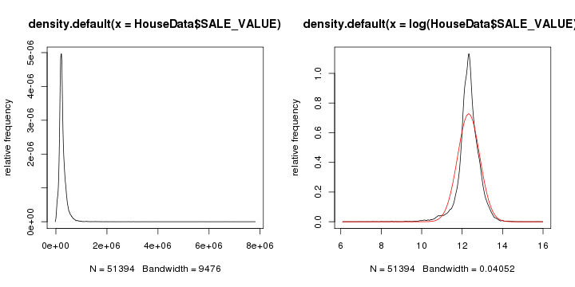

```r
par(mfrow = c(1, 2))
plot(density(HouseData$SALE_VALUE), ylab = "relative frequency")
plot(density(log(HouseData$SALE_VALUE)), ylab = "relative frequency")
curve(dnorm(x, mean = mean(log(HouseData$SALE_VALUE)), sd = sd(log(HouseData$SALE_VALUE))), add = TRUE, col = "red")
```

The following graphs show the distributions of our five Open Space Index variables. Notice that the OSI values are less skewed for the larger OSI radii. That is, the distribution of the OSI values for the 2km radius is more symmetrical than the OSI values for the .1km radius.

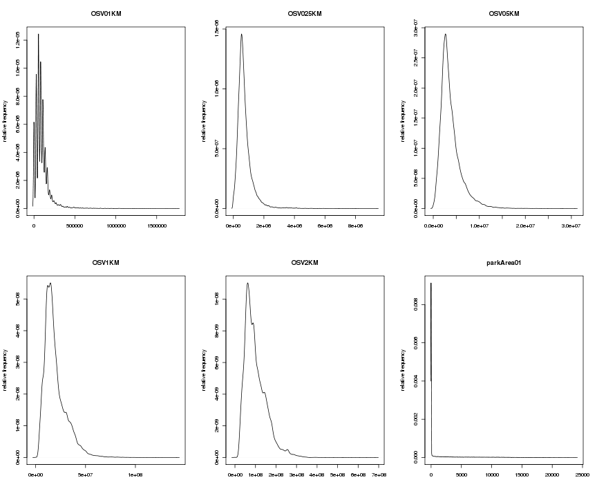

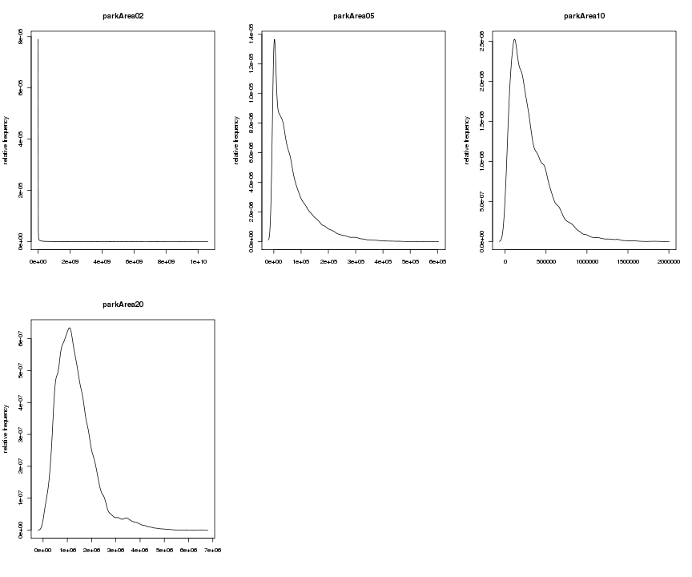

```r
par(mfrow = c(2, 3))
for (myVar in vars[-1]) {
    plot(density(HouseData[, myVar]), ylab = "relative frequency", xlab = "", main = myVar)
}
```

## Basic Hedonic Regression

Let's start constructing our basic hedonic regression by formally creating the logged sale price variable, converting a couple variables from string to numeric, and creating some time related variables (year of sale, month of sale, etc.).

```r
HouseData$logPRICE = log(HouseData$SALE_VALUE)
HouseData$GARAGEsqft = as.numeric(as.character(HouseData$GARAGESQFT))
HouseData$SALE_YEAR = 1900 + as.POSIXlt(HouseData$SALE_DATE)$year
HouseData$SALE_MONTH = 1 + as.POSIXlt(HouseData$SALE_DATE)$mon
HouseData$YEARMON = 12 * (HouseData$SALE_YEAR - 2009) + HouseData$SALE_MONTH  # number of months since january 1, 2009
```

```r
StructuralModel1 = lm(logPRICE ~ FIN_SQ_FT + ACRES_POLY + YEAR_BUILT, data = HouseData)
summary(StructuralModel1)
```

```
##
## Call:
## lm(formula = logPRICE ~ FIN_SQ_FT + ACRES_POLY + YEAR_BUILT,
##     data = HouseData)
##
## Residuals:
##    Min     1Q Median     3Q    Max
## -6.312 -0.159  0.051  0.228  3.353
##
## Coefficients:
##             Estimate Std. Error t value Pr(>|t|)
## (Intercept) 3.64e+00   1.35e-01    27.0   <2e-16 ***
## FIN_SQ_FT   3.54e-04   2.70e-06   131.1   <2e-16 ***
## ACRES_POLY  4.96e-02   2.30e-03    21.6   <2e-16 ***
## YEAR_BUILT  4.09e-03   6.86e-05    59.6   <2e-16 ***
## ---
## Signif. codes:  0 '***' 0.001 '**' 0.01 '*' 0.05 '.' 0.1 ' ' 1
##
## Residual standard error: 0.437 on 51390 degrees of freedom
## Multiple R-squared: 0.363,   Adjusted R-squared: 0.363
## F-statistic: 9.75e+03 on 3 and 51390 DF,  p-value: <2e-16
```

We now add fixed effects for the home's construction style to our regression equation in order to further explain another five percent of the variation in our logged sale price variable.

```r
StructuralModel2 = lm(logPRICE ~ FIN_SQ_FT + ACRES_POLY + YEAR_BUILT + HomeStyle, data = HouseData)
summary(StructuralModel2)
```

```
##
## Call:
## lm(formula = logPRICE ~ FIN_SQ_FT + ACRES_POLY + YEAR_BUILT +
##     HomeStyle, data = HouseData)
##
## Residuals:
##    Min     1Q Median     3Q    Max
## -6.333 -0.138  0.048  0.203  3.356
##
## Coefficients:
##                                          Estimate Std. Error t value Pr(>|t|)
## (Intercept)                              3.50e+00   1.91e-01   18.36  < 2e-16 ***
## FIN_SQ_FT                                3.28e-04   3.17e-06  103.38  < 2e-16 ***
## ACRES_POLY                               4.60e-02   2.25e-03   20.40  < 2e-16 ***
## YEAR_BUILT                               4.38e-03   9.53e-05   45.94  < 2e-16 ***
## HomeStyle1 Story                        -3.93e-01   2.25e-02  -17.47  < 2e-16 ***
## HomeStyle1 Story Brick                  -1.31e-01   2.44e-01   -0.54   0.5908
## HomeStyle1 Story Condo                  -9.39e-01   4.16e-02  -22.56  < 2e-16 ***
## HomeStyle1 Story Frame                  -3.27e-01   2.39e-02  -13.71  < 2e-16 ***
## HomeStyle1 Story Townhouse              -3.82e-01   2.67e-02  -14.29  < 2e-16 ***
## HomeStyle2 1/2 Story Finished           -7.89e-01   4.21e-01   -1.87   0.0610 .
## HomeStyle2 Story                        -3.20e-01   2.25e-02  -14.21  < 2e-16 ***
## HomeStyle2 Story Brick                  -1.56e-01   4.21e-01   -0.37   0.7116
## HomeStyle2 Story Condo                  -8.42e-01   3.01e-02  -28.00  < 2e-16 ***
## HomeStyle2 Story Frame                  -3.52e-01   2.32e-02  -15.16  < 2e-16 ***
## HomeStyle2 Story Townhouse              -7.67e-01   2.40e-02  -32.04  < 2e-16 ***
## HomeStyle3/2 Story                      -3.44e-01   3.09e-02  -11.15  < 2e-16 ***
## HomeStyle3-LVL SPLT                     -2.37e-01   3.76e-02   -6.30  3.0e-10 ***
## HomeStyle4 LVL SPLT                     -1.71e-01   3.35e-02   -5.12  3.1e-07 ***
## HomeStyle5/4 Story                      -3.17e-01   2.72e-02  -11.68  < 2e-16 ***
## HomeStyle7/4 Story                      -4.69e-01   2.56e-02  -18.30  < 2e-16 ***
## HomeStyleBi-level                       -2.73e-01   2.43e-02  -11.23  < 2e-16 ***
## HomeStyleBungalow                       -3.93e-01   2.37e-02  -16.57  < 2e-16 ***
## HomeStyleCabin                          -5.30e-01   4.21e-01   -1.26   0.2075
## HomeStyleCondo                          -8.96e-01   4.01e-02  -22.32  < 2e-16 ***
## HomeStyleDetached Townhome - 1 story    -7.98e-02   3.68e-02   -2.17   0.0300 *
## HomeStyleDetached Townhome - 2 story    -3.97e-01   5.94e-02   -6.69  2.2e-11 ***
## HomeStyleDetached Townhome - Split Foy*  2.53e-02   2.44e-01    0.10   0.9174
## HomeStyleDetached Townhome - Split lev* -2.09e-01   1.11e-01   -1.89   0.0592 .
## HomeStyleDouble bungalow - split foyer  -1.65e-01   4.21e-01   -0.39   0.6955
```

[output cut: 17 more lines]

```
## HomeStyleSplit Foyer Frame              -3.56e-01   2.43e-02  -14.65  < 2e-16 ***
## HomeStyleSplit Level                    -3.77e-01   2.26e-02  -16.71  < 2e-16 ***
## HomeStyleSplit Level Frame              -2.76e-01   2.57e-02  -10.74  < 2e-16 ***
## HomeStyleThree Story                    -6.99e-01   7.98e-02   -8.76  < 2e-16 ***
## HomeStyleTOWNHOME                       -5.01e-01   2.35e-02  -21.36  < 2e-16 ***
## HomeStyleTWIN HOME                      -3.56e-01   3.81e-02   -9.33  < 2e-16 ***
## HomeStyleTwin home - one story          -7.42e-01   9.22e-02   -8.05  8.7e-16 ***
## HomeStyleTwin home - spit level/ split* -7.25e-01   5.45e-02  -13.32  < 2e-16 ***
## HomeStyleTwin home - two story          -1.05e+00   1.42e-01   -7.41  1.3e-13 ***
## ---
## Signif. codes:  0 '***' 0.001 '**' 0.01 '*' 0.05 '.' 0.1 ' ' 1
##
## Residual standard error: 0.42 on 51339 degrees of freedom
## Multiple R-squared: 0.412,   Adjusted R-squared: 0.412
## F-statistic:  667 on 54 and 51339 DF,  p-value: <2e-16
```

Additional structural variables, such as the presence and type of cooling system are not reported for some counties in our study area and prevent us from including them in our regressions. We will rerun our regressions in the subset of area with cooling data to test the robustness of our results in a later section.

```r
table(is.na(HouseData$COOLING), HouseData$COUNTY_ID)
```

```
##
##           003   037   123   139   163
##   FALSE     0     0 14054     0 10841
##   TRUE   9479  9677     3  6919   421
```

## Adding Neighborhood Variables to the Regression

```r
neighborhoodModel1 = lm(logPRICE ~ FIN_SQ_FT + ACRES_POLY + YEAR_BUILT + HomeStyle + CITY + SCHOOL_DST + WhiteDense + fam_income, data = HouseData)
summary(neighborhoodModel1)
```

```
##
## Call:
## lm(formula = logPRICE ~ FIN_SQ_FT + ACRES_POLY + YEAR_BUILT +
##     HomeStyle + CITY + SCHOOL_DST + WhiteDense + fam_income,
##     data = HouseData)
##
## Residuals:
##    Min     1Q Median     3Q    Max
## -6.548 -0.121  0.036  0.178  3.246
##
## Coefficients: (4 not defined because of singularities)
##                                          Estimate Std. Error t value Pr(>|t|)
## (Intercept)                              4.61e+00   2.38e-01   19.34  < 2e-16 ***
## FIN_SQ_FT                                3.46e-04   3.88e-06   89.15  < 2e-16 ***
## ACRES_POLY                               3.62e-02   2.59e-03   13.99  < 2e-16 ***
## YEAR_BUILT                               3.22e-03   1.16e-04   27.67  < 2e-16 ***
## HomeStyle1 Story                        -9.68e-03   2.31e-02   -0.42  0.67492
## HomeStyle1 Story Brick                   8.72e-01   4.13e-01    2.11  0.03460 *
## HomeStyle1 Story Condo                  -3.45e-02   1.30e-01   -0.27  0.79060
## HomeStyle1 Story Frame                   5.50e-01   1.23e-01    4.46  8.3e-06 ***
## HomeStyle1 Story Townhouse               4.92e-01   1.25e-01    3.93  8.6e-05 ***
## HomeStyle2 1/2 Story Finished           -3.76e-01   4.00e-01   -0.94  0.34732
## HomeStyle2 Story                         4.53e-03   2.23e-02    0.20  0.83905
## HomeStyle2 Story Condo                  -3.43e-02   1.28e-01   -0.27  0.78892
## HomeStyle2 Story Frame                   4.89e-01   1.23e-01    3.97  7.3e-05 ***
## HomeStyle2 Story Townhouse               1.62e-01   1.23e-01    1.32  0.18829
## HomeStyle3/2 Story                      -2.98e-02   3.11e-02   -0.96  0.33804
## HomeStyle3-LVL SPLT                     -2.34e-01   3.50e-02   -6.68  2.4e-11 ***
## HomeStyle4 LVL SPLT                     -1.55e-01   3.13e-02   -4.94  7.8e-07 ***
## HomeStyle5/4 Story                      -1.50e-04   2.78e-02   -0.01  0.99570
## HomeStyle7/4 Story                      -4.58e-02   2.54e-02   -1.80  0.07145 .
## HomeStyleBi-level                        1.18e-01   2.52e-02    4.67  3.0e-06 ***
## HomeStyleBungalow                       -1.36e-02   2.40e-02   -0.57  0.57137
## HomeStyleCabin                          -2.32e-01   3.91e-01   -0.59  0.55283
## HomeStyleCondo                          -9.16e-01   3.80e-02  -24.12  < 2e-16 ***
## HomeStyleDetached Townhome - 1 story     2.62e-01   3.60e-02    7.27  3.5e-13 ***
## HomeStyleDetached Townhome - 2 story    -4.73e-02   5.92e-02   -0.80  0.42486
## HomeStyleDetached Townhome - Split Foy*  3.68e-01   2.27e-01    1.62  0.10424
## HomeStyleDetached Townhome - Split lev*  1.78e-01   1.04e-01    1.71  0.08724 .
## HomeStyleDouble bungalow - split foyer   1.77e-01   3.92e-01    0.45  0.65252
```

[output cut: 114 more lines]

```
## SCHOOL_DST831                                  NA         NA      NA       NA
## SCHOOL_DSTISD622                        -5.75e-02   1.07e-01   -0.54  0.59194
## SCHOOL_DSTISD624                        -1.74e-01   1.91e-01   -0.91  0.36449
## SCHOOL_DSTISD831                        -5.08e-01   2.10e-01   -2.42  0.01544 *
## SCHOOL_DSTISD832                        -3.33e-02   1.53e-01   -0.22  0.82761
## SCHOOL_DSTISD833                               NA         NA      NA       NA
## WhiteDense                               8.48e-01   1.22e-02   69.75  < 2e-16 ***
## fam_income                               1.13e-06   1.25e-07    9.03  < 2e-16 ***
## ---
## Signif. codes:  0 '***' 0.001 '**' 0.01 '*' 0.05 '.' 0.1 ' ' 1
##
## Residual standard error: 0.39 on 43710 degrees of freedom
##   (7538 observations deleted due to missingness)
## Multiple R-squared: 0.501,   Adjusted R-squared: 0.499
## F-statistic:  302 on 145 and 43710 DF,  p-value: <2e-16
```

```r
neighborhoodModel2 = lm(logPRICE ~ FIN_SQ_FT + ACRES_POLY + YEAR_BUILT + HomeStyle + ELEMENTARY + WhiteDense + fam_income, data = HouseData)
summary(neighborhoodModel2)
```

```
##
## Call:
## lm(formula = logPRICE ~ FIN_SQ_FT + ACRES_POLY + YEAR_BUILT +
##     HomeStyle + ELEMENTARY + WhiteDense + fam_income, data = HouseData)
##
## Residuals:
##    Min     1Q Median     3Q    Max
## -6.834 -0.108  0.034  0.169  3.191
##
## Coefficients:
##                                              Estimate Std. Error t value Pr(>|t|)
## (Intercept)                                  3.48e+00   2.20e-01   15.84  < 2e-16 ***
## FIN_SQ_FT                                    3.29e-04   3.45e-06   95.11  < 2e-16 ***
## ACRES_POLY                                   4.02e-02   2.13e-03   18.88  < 2e-16 ***
## YEAR_BUILT                                   4.00e-03   1.10e-04   36.47  < 2e-16 ***
## HomeStyle1 Story                            -1.59e-02   2.17e-02   -0.73  0.46429
## HomeStyle1 Story Brick                       3.60e-01   2.14e-01    1.68  0.09254 .
## HomeStyle1 Story Condo                      -4.65e-01   4.36e-02  -10.65  < 2e-16 ***
## HomeStyle1 Story Frame                       1.54e-01   3.10e-02    4.96  7.1e-07 ***
## HomeStyle1 Story Townhouse                   8.49e-02   3.32e-02    2.56  0.01048 *
## HomeStyle2 1/2 Story Finished               -3.65e-01   3.68e-01   -0.99  0.32058
## HomeStyle2 Story                            -1.88e-02   2.10e-02   -0.90  0.37029
## HomeStyle2 Story Brick                       1.68e-01   3.68e-01    0.46  0.64722
## HomeStyle2 Story Condo                      -3.49e-01   3.59e-02   -9.71  < 2e-16 ***
## HomeStyle2 Story Frame                       8.16e-02   3.08e-02    2.65  0.00812 **
## HomeStyle2 Story Townhouse                  -2.61e-01   3.12e-02   -8.36  < 2e-16 ***
## HomeStyle3/2 Story                          -4.02e-02   2.85e-02   -1.41  0.15896
## HomeStyle3-LVL SPLT                         -2.30e-01   3.30e-02   -6.96  3.5e-12 ***
## HomeStyle4 LVL SPLT                         -1.39e-01   2.95e-02   -4.73  2.2e-06 ***
## HomeStyle5/4 Story                          -7.82e-03   2.61e-02   -0.30  0.76408
## HomeStyle7/4 Story                           4.02e-03   2.39e-02    0.17  0.86657
## HomeStyleBi-level                            8.48e-02   2.37e-02    3.57  0.00035 ***
## HomeStyleBungalow                            2.77e-03   2.27e-02    0.12  0.90262
## HomeStyleCabin                              -2.47e-01   3.67e-01   -0.67  0.50212
## HomeStyleCondo                              -8.99e-01   3.67e-02  -24.47  < 2e-16 ***
## HomeStyleDetached Townhome - 1 story         2.45e-01   3.45e-02    7.09  1.3e-12 ***
## HomeStyleDetached Townhome - 2 story        -2.95e-02   5.46e-02   -0.54  0.58935
## HomeStyleDetached Townhome - Split Foy*      3.36e-01   2.13e-01    1.57  0.11558
## HomeStyleDetached Townhome - Split lev*      1.78e-01   9.88e-02    1.80  0.07231 .
## HomeStyleDouble bungalow - split foyer       1.93e-01   3.68e-01    0.52  0.60075
```

[output cut: 214 more lines]

```
## ELEMENTARYWILLOW LANE                       -2.00e-02   3.96e-02   -0.51  0.61315
## ELEMENTARYWILSHIRE PARK                      1.15e-01   6.81e-02    1.69  0.09135 .
## ELEMENTARYWILSON                            -5.86e-02   3.57e-02   -1.64  0.10098
## ELEMENTARYWOODBURY                          -1.07e-02   3.66e-02   -0.29  0.76980
## ELEMENTARYWOODCREST                          1.74e-01   2.71e-02    6.42  1.4e-10 ***
## ELEMENTARYWOODCREST & WESTWOOD              -7.51e-02   2.60e-01   -0.29  0.77269
## ELEMENTARYWOODLAND                           7.68e-02   3.80e-02    2.02  0.04310 *
## WhiteDense                                   4.97e-01   1.20e-02   41.29  < 2e-16 ***
## fam_income                                  -1.08e-06   1.24e-07   -8.70  < 2e-16 ***
## ---
## Signif. codes:  0 '***' 0.001 '**' 0.01 '*' 0.05 '.' 0.1 ' ' 1
##
## Residual standard error: 0.366 on 51142 degrees of freedom
## Multiple R-squared: 0.556,   Adjusted R-squared: 0.553
## F-statistic:  255 on 251 and 51142 DF,  p-value: <2e-16
```

## Time

The years of 2005 - 2011 were different for the real estate market relative to the early years of the 2000s. We now incorporate fixed effects for the sale year and month of sale to limit the confounding effects of the changing real estate conditions.

- Here we should create a graph of sales price indices for the region (such as Case Schiller) and the nation.

```r
TimeModel1 = lm(logPRICE ~ FIN_SQ_FT + ACRES_POLY + YEAR_BUILT + HomeStyle + ELEMENTARY + WhiteDense + fam_income + factor(SALE_YEAR) + factor(SALE_MONTH), data = HouseData)
summary(TimeModel1)
```

```
##
## Call:
## lm(formula = logPRICE ~ FIN_SQ_FT + ACRES_POLY + YEAR_BUILT +
##     HomeStyle + ELEMENTARY + WhiteDense + fam_income + factor(SALE_YEAR) +
##     factor(SALE_MONTH), data = HouseData)
##
## Residuals:
##    Min     1Q Median     3Q    Max
## -7.011 -0.101  0.023  0.153  3.187
##
## Coefficients:
##                                              Estimate Std. Error t value Pr(>|t|)
## (Intercept)                                  4.69e+00   2.08e-01   22.57  < 2e-16 ***
## FIN_SQ_FT                                    3.10e-04   3.26e-06   95.06  < 2e-16 ***
## ACRES_POLY                                   4.05e-02   2.01e-03   20.16  < 2e-16 ***
## YEAR_BUILT                                   3.35e-03   1.04e-04   32.30  < 2e-16 ***
## HomeStyle1 Story                             2.14e-03   2.05e-02    0.10  0.91661
## HomeStyle1 Story Brick                       2.34e-01   2.01e-01    1.16  0.24434
## HomeStyle1 Story Condo                      -5.04e-01   4.11e-02  -12.25  < 2e-16 ***
## HomeStyle1 Story Frame                       1.29e-01   2.92e-02    4.42  9.8e-06 ***
## HomeStyle1 Story Townhouse                   6.06e-02   3.13e-02    1.94  0.05267 .
## HomeStyle2 1/2 Story Finished               -1.89e-01   3.46e-01   -0.55  0.58544
## HomeStyle2 Story                            -1.66e-02   1.98e-02   -0.84  0.40158
## HomeStyle2 Story Brick                       1.47e-01   3.46e-01    0.42  0.67198
## HomeStyle2 Story Condo                      -4.48e-01   3.39e-02  -13.24  < 2e-16 ***
## HomeStyle2 Story Frame                       6.13e-02   2.90e-02    2.11  0.03467 *
## HomeStyle2 Story Townhouse                  -3.19e-01   2.94e-02  -10.86  < 2e-16 ***
## HomeStyle3/2 Story                          -2.27e-02   2.69e-02   -0.85  0.39769
## HomeStyle3-LVL SPLT                         -1.91e-01   3.11e-02   -6.14  8.4e-10 ***
## HomeStyle4 LVL SPLT                         -1.18e-01   2.78e-02   -4.27  2.0e-05 ***
## HomeStyle5/4 Story                           1.33e-02   2.46e-02    0.54  0.58669
## HomeStyle7/4 Story                           1.09e-02   2.26e-02    0.48  0.63043
## HomeStyleBi-level                            8.73e-02   2.23e-02    3.91  9.4e-05 ***
## HomeStyleBungalow                            1.48e-02   2.13e-02    0.69  0.48935
## HomeStyleCabin                              -3.37e-01   3.46e-01   -0.97  0.33011
## HomeStyleCondo                              -8.41e-01   3.46e-02  -24.29  < 2e-16 ***
## HomeStyleDetached Townhome - 1 story         2.20e-01   3.25e-02    6.78  1.2e-11 ***
## HomeStyleDetached Townhome - 2 story        -2.14e-02   5.14e-02   -0.42  0.67761
## HomeStyleDetached Townhome - Split Foy*      3.92e-01   2.01e-01    1.95  0.05148 .
## HomeStyleDetached Townhome - Split lev*      1.94e-01   9.31e-02    2.09  0.03671 *
```

[output cut: 230 more lines]

```
## factor(SALE_MONTH)4                          8.27e-03   8.30e-03    1.00  0.31944
## factor(SALE_MONTH)5                          3.92e-02   8.19e-03    4.78  1.7e-06 ***
## factor(SALE_MONTH)6                          4.46e-02   8.02e-03    5.55  2.8e-08 ***
## factor(SALE_MONTH)7                          4.41e-02   8.31e-03    5.31  1.1e-07 ***
## factor(SALE_MONTH)8                          4.49e-02   8.24e-03    5.44  5.3e-08 ***
## factor(SALE_MONTH)9                          2.71e-02   8.49e-03    3.19  0.00141 **
## factor(SALE_MONTH)10                         3.98e-02   8.55e-03    4.66  3.2e-06 ***
## factor(SALE_MONTH)11                         5.87e-03   8.83e-03    0.66  0.50631
## factor(SALE_MONTH)12                        -6.10e-03   9.13e-03   -0.67  0.50401
## ---
## Signif. codes:  0 '***' 0.001 '**' 0.01 '*' 0.05 '.' 0.1 ' ' 1
##
## Residual standard error: 0.345 on 51127 degrees of freedom
## Multiple R-squared: 0.606,   Adjusted R-squared: 0.604
## F-statistic:  295 on 266 and 51127 DF,  p-value: <2e-16
```

## Open Space

Now we'll bring in the open space measures, both Open Space Index and park area.

```r
osiModel05int = lm(logPRICE ~ FIN_SQ_FT + ACRES_POLY + YEAR_BUILT + HomeStyle + ELEMENTARY + WhiteDense + fam_income + factor(SALE_MONTH) + parkArea05 * factor(SALE_YEAR) +
    OSV05KM * factor(SALE_YEAR), data = HouseData)
coef(summary(osiModel05int))[-(5:250), ]
```

```
##                                    Estimate Std. Error  t value   Pr(>|t|)
## (Intercept)                       4.746e+00  2.080e-01  22.8151 1.216e-114
## FIN_SQ_FT                         3.096e-04  3.272e-06  94.6327  0.000e+00
## ACRES_POLY                        4.001e-02  2.053e-03  19.4866  2.886e-84
## YEAR_BUILT                        3.318e-03  1.039e-04  31.9412 1.099e-221
## WhiteDense                        1.935e-01  1.200e-02  16.1278  2.270e-58
## fam_income                        4.586e-06  1.386e-07  33.0839 1.653e-237
## factor(SALE_MONTH)2              -1.297e-02  9.102e-03  -1.4254  1.540e-01
## factor(SALE_MONTH)3               1.419e-02  8.469e-03   1.6752  9.389e-02
## factor(SALE_MONTH)4               9.592e-03  8.301e-03   1.1555  2.479e-01
## factor(SALE_MONTH)5               4.054e-02  8.189e-03   4.9508  7.416e-07
## factor(SALE_MONTH)6               4.586e-02  8.017e-03   5.7208  1.066e-08
## factor(SALE_MONTH)7               4.535e-02  8.305e-03   5.4602  4.778e-08
## factor(SALE_MONTH)8               4.602e-02  8.239e-03   5.5854  2.344e-08
## factor(SALE_MONTH)9               2.825e-02  8.482e-03   3.3306  8.671e-04
## factor(SALE_MONTH)10              4.094e-02  8.549e-03   4.7891  1.680e-06
## factor(SALE_MONTH)11              7.414e-03  8.826e-03   0.8401  4.009e-01
## factor(SALE_MONTH)12             -4.480e-03  9.123e-03  -0.4911  6.234e-01
## parkArea05                        2.250e-08  3.859e-08   0.5830  5.599e-01
## factor(SALE_YEAR)2006            -2.477e-04  8.121e-03  -0.0305  9.757e-01
## factor(SALE_YEAR)2009            -3.573e-01  9.711e-03 -36.7890 1.870e-292
## factor(SALE_YEAR)2010            -3.803e-01  1.031e-02 -36.8971 3.844e-294
## factor(SALE_YEAR)2011            -5.967e-01  1.906e-02 -31.3090 3.685e-213
## OSV05KM                           3.455e-10  1.371e-09   0.2519  8.011e-01
## parkArea05:factor(SALE_YEAR)2006 -5.125e-08  5.436e-08  -0.9428  3.458e-01
## parkArea05:factor(SALE_YEAR)2009  2.370e-07  6.281e-08   3.7739  1.609e-04
## parkArea05:factor(SALE_YEAR)2010 -3.747e-08  6.548e-08  -0.5723  5.671e-01
## parkArea05:factor(SALE_YEAR)2011  5.812e-07  1.252e-07   4.6406  3.483e-06
## factor(SALE_YEAR)2006:OSV05KM     2.657e-09  1.818e-09   1.4619  1.438e-01
## factor(SALE_YEAR)2009:OSV05KM     5.255e-10  2.031e-09   0.2587  7.958e-01
## factor(SALE_YEAR)2010:OSV05KM     6.537e-09  2.140e-09   3.0543  2.257e-03
## factor(SALE_YEAR)2011:OSV05KM     1.410e-08  4.223e-09   3.3388  8.421e-04
```

Now let's get a table of residuals for osiModel05int

```r
ResidTable = ("~/OSI-Hedonic Project/Data/R2GIS/ResidTableOSV05Int.dbf")
ResidFrame = data.frame(HouseData$MYPIN)
colnames(ResidFrame)[1] = "MYPIN"
ResidFrame$RESID = resid(osiModel05int)
ResidFrame$FIT = fitted(osiModel05int)
write.dbf(ResidFrame, ResidTable)
```

Now I want to try running a model without any outliers in it, classified in the Outliers column. Now write residuals somewhere new.

```r
HouseDataClean = subset(HouseData, Outliers == 0)
osiModel05intClean = lm(logPRICE ~ FIN_SQ_FT + ACRES_POLY + YEAR_BUILT + HomeStyle + ELEMENTARY + WhiteDense + fam_income + factor(SALE_MONTH) + parkArea05 * factor(SALE_YEAR) +
    OSV05KM * factor(SALE_YEAR), data = HouseDataClean)
coef(summary(osiModel05intClean))[-(5:250), ]
```

```
##                                    Estimate Std. Error   t value   Pr(>|t|)
## (Intercept)                       4.780e+00  2.071e-01  23.08489 2.623e-117
## FIN_SQ_FT                         3.099e-04  3.260e-06  95.05699  0.000e+00
## ACRES_POLY                        3.738e-02  2.096e-03  17.83152  6.605e-71
## YEAR_BUILT                        3.300e-03  1.034e-04  31.91004 2.920e-221
## WhiteDense                        1.982e-01  1.195e-02  16.59196  1.156e-61
## fam_income                        4.572e-06  1.380e-07  33.12978 3.733e-238
## factor(SALE_MONTH)2              -1.248e-02  9.060e-03  -1.37791  1.682e-01
## factor(SALE_MONTH)3               1.468e-02  8.430e-03   1.74086  8.171e-02
## factor(SALE_MONTH)4               1.008e-02  8.263e-03   1.21947  2.227e-01
## factor(SALE_MONTH)5               4.054e-02  8.152e-03   4.97270  6.624e-07
## factor(SALE_MONTH)6               4.630e-02  7.980e-03   5.80218  6.584e-09
## factor(SALE_MONTH)7               4.579e-02  8.268e-03   5.53879  3.061e-08
## factor(SALE_MONTH)8               4.491e-02  8.203e-03   5.47478  4.401e-08
## factor(SALE_MONTH)9               2.802e-02  8.444e-03   3.31867  9.051e-04
## factor(SALE_MONTH)10              4.142e-02  8.510e-03   4.86650  1.139e-06
## factor(SALE_MONTH)11              7.202e-03  8.786e-03   0.81975  4.124e-01
## factor(SALE_MONTH)12             -4.931e-03  9.082e-03  -0.54296  5.872e-01
## parkArea05                        1.718e-08  3.841e-08   0.44734  6.546e-01
## factor(SALE_YEAR)2006             2.187e-03  8.087e-03   0.27044  7.868e-01
## factor(SALE_YEAR)2009            -3.565e-01  9.668e-03 -36.87995 7.136e-294
## factor(SALE_YEAR)2010            -3.789e-01  1.026e-02 -36.92932 1.208e-294
## factor(SALE_YEAR)2011            -5.955e-01  1.897e-02 -31.38992 3.049e-214
## OSV05KM                           6.559e-10  1.366e-09   0.48017  6.311e-01
## parkArea05:factor(SALE_YEAR)2006 -5.463e-08  5.412e-08  -1.00935  3.128e-01
## parkArea05:factor(SALE_YEAR)2009  2.474e-07  6.252e-08   3.95681  7.606e-05
## parkArea05:factor(SALE_YEAR)2010 -3.482e-08  6.518e-08  -0.53424  5.932e-01
## parkArea05:factor(SALE_YEAR)2011  5.852e-07  1.247e-07   4.69447  2.680e-06
## factor(SALE_YEAR)2006:OSV05KM     1.997e-09  1.810e-09   1.10338  2.699e-01
## factor(SALE_YEAR)2009:OSV05KM     1.867e-10  2.022e-09   0.09234  9.264e-01
## factor(SALE_YEAR)2010:OSV05KM     6.293e-09  2.130e-09   2.95401  3.138e-03
## factor(SALE_YEAR)2011:OSV05KM     1.380e-08  4.203e-09   3.28303  1.028e-03
```

```r
ResidTableC = ("~/OSI-Hedonic Project/Data/R2GIS/ResidTableOSV05IntCleaned.dbf")
ResidFrameC = data.frame(HouseDataClean$MYPIN)
colnames(ResidFrameC)[1] = "MYPIN"
ResidFrameC$RESID = resid(osiModel05intClean)
ResidFrameC$FIT = fitted(osiModel05intClean)
write.dbf(ResidFrameC, ResidTableC)
```